# Consumer Adoption of Autonomous Robots for Last-Mile Deliveries

Final Analysis

Author

Adwoa Darko , Siddharth Kusuma, Sudeep Januga

Published

December 12, 2025

# Abstract

This study investigates consumer adoption of autonomous delivery technologies—specifically robots and drones for last-mile delivery. The project explores how customers trade off between key delivery attributes: price, speed, environmental sustainability (CO₂ emissions), reliability, and delivery mode (Truck, Robot, Drone). A pilot conjoint survey was conducted among frequent e-commerce shoppers who regularly order small and light packages (under 10 lbs).

# Introduction

The rapid rise of e-commerce has led to an exponential increase in small-package deliveries, making the last-mile segment both critical and costly for logistics companies. Autonomous delivery technologies such as ground robots and drones are being developed to make deliveries faster, cheaper, and more sustainable, but public acceptance remains uncertain. Understanding how consumers value attributes like delivery cost, time, and sustainability is essential before large-scale deployment.

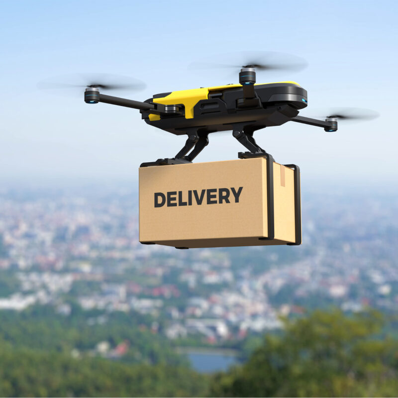

This study focuses on evaluating consumer preferences for different delivery modes (Truck, Robot, Drone) and the trade-offs among four major attributes: Price, Speed, CO₂ Emissions, and Reliability. Each attribute was varied at realistic market levels to simulate decision-making scenarios. For example, prices ranged from $2 to $8, speeds from 30 minutes to 24 hours, emissions from 2 lb to 0.001 lb of CO₂ per mile, and reliability from 85% to 95%. A choice-based conjoint (CBC) survey was designed to estimate the relative importance of each attribute.

The analysis contributes to the broader policy discussion on the sustainability and feasibility of autonomous last-mile systems, offering insights into consumer willingness to adopt technology-driven delivery methods that could reduce emissions and traffic congestion.

# Survey Design

## Eligibility and Target Population

The target population comprised frequent online shoppers who regularly receive small or light packages (under 10 lbs). Eligibility criteria ensured relevance to real-world robot delivery applications:

- Must order from e-commerce retailers such as Amazon, Walmart, or Target.
- Receive at least one package per month.
- Typically receive small or light items such as books, electronics, or clothing.
- Respondents who only receive large or heavy packages were excluded

## Data Collected

The survey collected the following key information:

- **Demographics**: age, gender, education level, household income, and residential area.
- **Behavioral variables**: online shopping frequency, number of monthly packages, delivery urgency, and typical spending on delivery fees.
- **Attitudinal measures**: environmental concern, trust in autonomous delivery, and comfort level with robots or drones

## Educational Material

Before choice questions, respondents viewed a brief educational page explaining each delivery attribute in plain language:

- **Price**: delivery fee in dollars.
- **Speed**: delivery time (e.g., 30 minutes, 1 hour, or 12–24 hours).
- **Sustainability (CO₂ emissions)**: pounds of CO₂ per mile emitted during delivery, with examples comparing truck and drone emissions.
- **Reliability & Safety**: the likelihood that a package arrives on time and undamaged

This step ensured all respondents understood trade-offs before making their choices.

## Conjoint Design

Each respondent answered six choice-based conjoint questions, each presenting three delivery options with randomized attribute combinations. No “none” option was included, compelling a realistic trade-off.

Attributes and Levels:

| **Attribute** | **Levels** | **Unit** |
| --- | --- | --- |
| **Price** | 2, 5, 8 | $ (dollars) |
| **Speed** | 12-24 hrs, 60 min, 30 min | Time in min & hrs |
| **Sustainability** | 2, 0.05, 0.001 | Pounds of CO₂ per mile |
| **Reliability & Safety** | 85%, 90%, 95% | % successful delivery |

## Example Question

[figure not shown]

# Data Analysis

## Sample Description

Respondents range from early 20s to over 70 years old, with the age distribution centered in the late 30s to mid‑40s, as shown in the age histogram. Gender is approximately balanced, with slightly more women than men and a very small number of non‑binary respondents.

Household income is concentrated in the middle ranges, with many respondents between 40,000 and 149,000 USD per year and fewer at the very low or very high ends of the distribution. Package delivery is already a routine activity for this group: most respondents receive packages once a week or several times per week, and only a small minority report rarely receiving packages

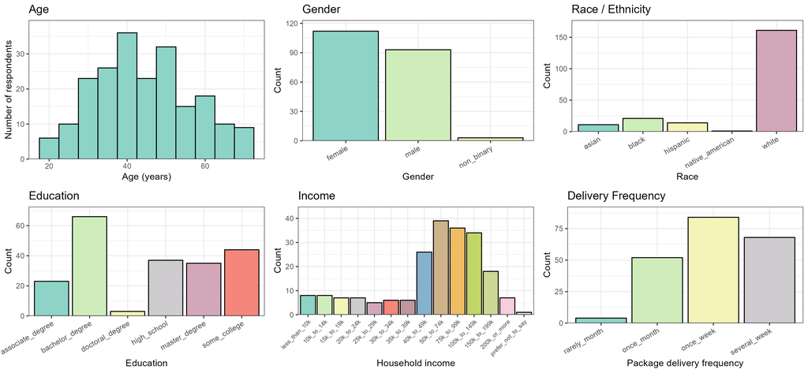

## Data Cleaning

We began with **215 total survey attempts** in the final deployment. The first quality step was to remove respondents who failed the built-in eligibility screener. In this survey, individuals were screened out if they did not meet the study’s basic criteria—for example, not being an active e-commerce shopper or indicating that they do not order small/light packages. After filtering out screened respondents, **204 responses remained**. This step ensures that the analysis reflects the intended target population of online shoppers whose delivery preferences are meaningful for the study.

Next, we restricted the dataset to respondents who **completed all six choice-based conjoint (CBC) tasks**. Anyone missing one or more CBC questions was removed, reducing the dataset from 204 to **201 respondents**. We then applied a standard “flatliner” check to identify respondents who selected the **exact same alternative in every choice task**, a behavior that typically signals low engagement or satisficing rather than thoughtful trade-off evaluation. Respondents exhibiting this pattern were removed, leaving **198 valid respondents** after this step.

Finally, we screened for unrealistic completion times, which help identify respondents who may have rushed through the survey without adequately processing the attribute information. We converted total response time into minutes and examined the distribution. Based on this, we excluded respondents who completed the choice-task portion in **under 5 minutes**, a threshold indicating insufficient cognitive effort for evaluating six multi-attribute profiles. After applying the time-quality filter, the final analytic sample consisted of **165 high-quality, engaged respondents**. Thus, out of the original 215 survey attempts, **50 respondents were removed** across screening, completeness, behavioral, and speed checks, ensuring that the remaining dataset was reliable, attentive, and appropriate for estimating the conjoint preference models.

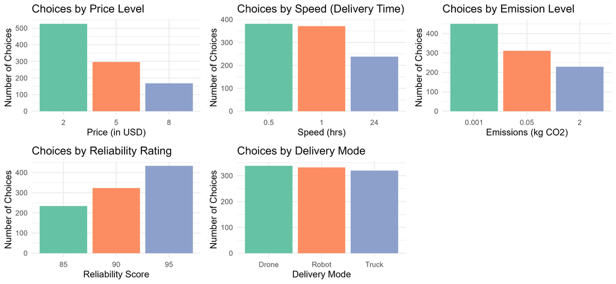

## Modeling

### Simple Logit Model

We estimated a Simple Logit model to quantify how each delivery attribute influenced respondents’ choices in the conjoint experiment.

$$u_j = \beta_1 x_j^{\mathrm{price}} + \beta_2 x_j^{\mathrm{speed}} + \beta_3 x_j^{\mathrm{emissions}} + \beta_4 x_j^{\mathrm{reliability}} + \beta_5 \delta_j^{\mathrm{Robot}} + \beta_6 \delta_j^{\mathrm{Drone}}$$
The results for the logit model are summarized below:

| parameter | Estimate | Std_Error | Z_value | P_value | Sig |
| --- | --- | --- | --- | --- | --- |
| price | -0.3564 | 0.0217 | -16.39 | <0.001 | *** |
| speed | -0.0349 | 0.0045 | -7.82 | <0.001 | *** |
| emissions | -0.5792 | 0.0541 | -10.70 | <0.001 | *** |
| reliability | 0.1069 | 0.0119 | 9.00 | <0.001 | *** |
| delivery_modeRobot | -0.0053 | 0.1123 | -0.05 | 0.9620 |  |
| delivery_modeDrone | 0.0765 | 0.1131 | 0.68 | 0.4988 |  |

The multinomial logit results indicate that several delivery attributes strongly influence consumer choice, while others have minimal impact. **Price**, **emissions**, and **reliability** emerge as the most important drivers of preference. Higher prices and higher CO₂ emissions significantly **reduce** the likelihood that a delivery option is chosen, with emissions showing one of the strongest negative effects, suggesting that respondents place meaningful value on environmentally friendly delivery methods. **Reliability** has a positive and highly significant effect, indicating that consumers prefer options they can depend on. **Speed** also matters, with slower delivery times reducing choice probability, though its effect is smaller than that of price or emissions. In contrast, the **delivery mode** itself—whether a package is delivered by a **robot** or **drone**—shows no statistically significant impact, meaning respondents do not strongly prefer or avoid these newer delivery technologies relative to traditional truck delivery. Overall, consumers prioritize **cost, environmental impact, and performance-related attributes** over the specific technology used to deliver their packages.

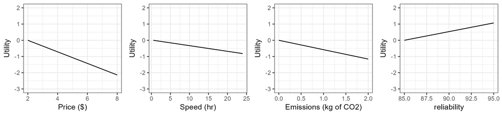

### Mixed Logit

| parameter | Estimate | Std_Error | Z_value | P_value | Sig |
| --- | --- | --- | --- | --- | --- |
| price | -0.5109 | 0.0696 | -7.34 | <0.001 | *** |
| speed | -0.0559 | 0.0120 | -4.65 | <0.001 | *** |
| emissions | -0.8843 | 0.1549 | -5.71 | <0.001 | *** |
| reliability | 0.1552 | 0.0277 | 5.61 | <0.001 | *** |
| delivery_mode_Drone | 0.2141 | 0.2443 | 0.88 | 0.381 |  |
| delivery_mode_Robot | -0.2531 | 0.1925 | -1.31 | 0.189 |  |
| sd_speed | 0.0698 | 0.0270 | 2.58 | 0.009 | ** |
| sd_emissions | 0.9519 | 0.2775 | 3.43 | 0.0006 | *** |
| sd_reliability | -0.1534 | 0.0692 | -2.22 | 0.027 | * |
| sd_delivery_mode_Drone | 0.3441 | 0.9495 | 0.36 | 0.717 |  |
| sd_delivery_mode_Robot | -1.4459 | 0.5981 | -2.42 | 0.016 | * |

### Subgroup Logit Model

| Attribute | Group A Mean | A 95% CI Lower | A 95% CI Upper | Group B Mean | B 95% CI Lower | B 95% CI Upper |
| --- | --- | --- | --- | --- | --- | --- |
| speed | -0.098 | -0.137 | -0.061 | -0.096 | -0.132 | -0.063 |
| emissions | -1.147 | -1.601 | -0.730 | -1.932 | -2.394 | -1.524 |
| reliability | 0.214 | 0.117 | 0.316 | 0.357 | 0.265 | 0.459 |
| delivery_mode_Drone | 0.265 | -0.657 | 1.179 | 0.209 | -0.654 | 1.072 |
| delivery_mode_Robot | 0.199 | -0.723 | 1.098 | -0.106 | -0.939 | 0.751 |

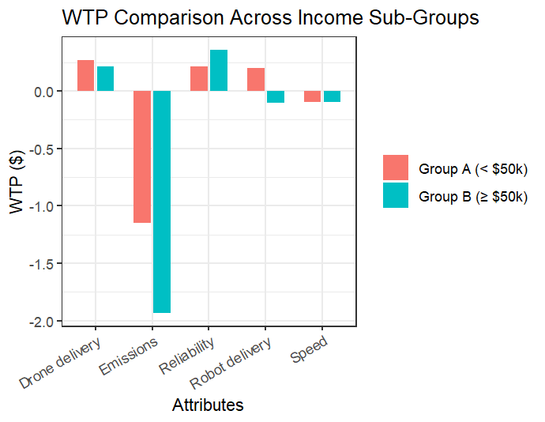

# Results

## WTP

| Attribute | Mean WTP ($) | Lower 95% CI | Upper 95% CI |
| --- | --- | --- | --- |
| **Speed** | -0.098 | -0.124 | -0.073 |
| **Emissions** | -1.628 | -1.955 | -1.323 |
| **Reliability** | 0.300 | 0.233 | 0.371 |
| **Drone delivery** | 0.220 | -0.404 | 0.844 |
| **Robot delivery** | -0.012 | -0.619 | 0.607 |

[figure not shown]

## Market Simulation

To evaluate how key delivery attributes influence consumer choice, a set of structured market simulation scenarios was created. Each scenario isolates one attribute—price, emissions, delivery mode, reliability, or speed—while holding the remaining attributes constant. This allows for a clear understanding of how each attribute independently shifts market share among competing alternatives.

The baseline attribute levels reflect realistic ranges used in the conjoint survey:

- Price: $2, $5, $8
- Speed: 24 hr, 1 hr, 0.5 hr
- Emissions: 2 lb, 0.05 lb, 0.001 lb CO₂
- Reliability: 85%, 90%, 95%
- Delivery Mode: Truck, Drone, Robot

These values were selected because they span low, medium, and high performance levels while remaining consistent with the respondents’ choice tasks. The simulations help illustrate competitive positioning when one attribute improves or worsens.

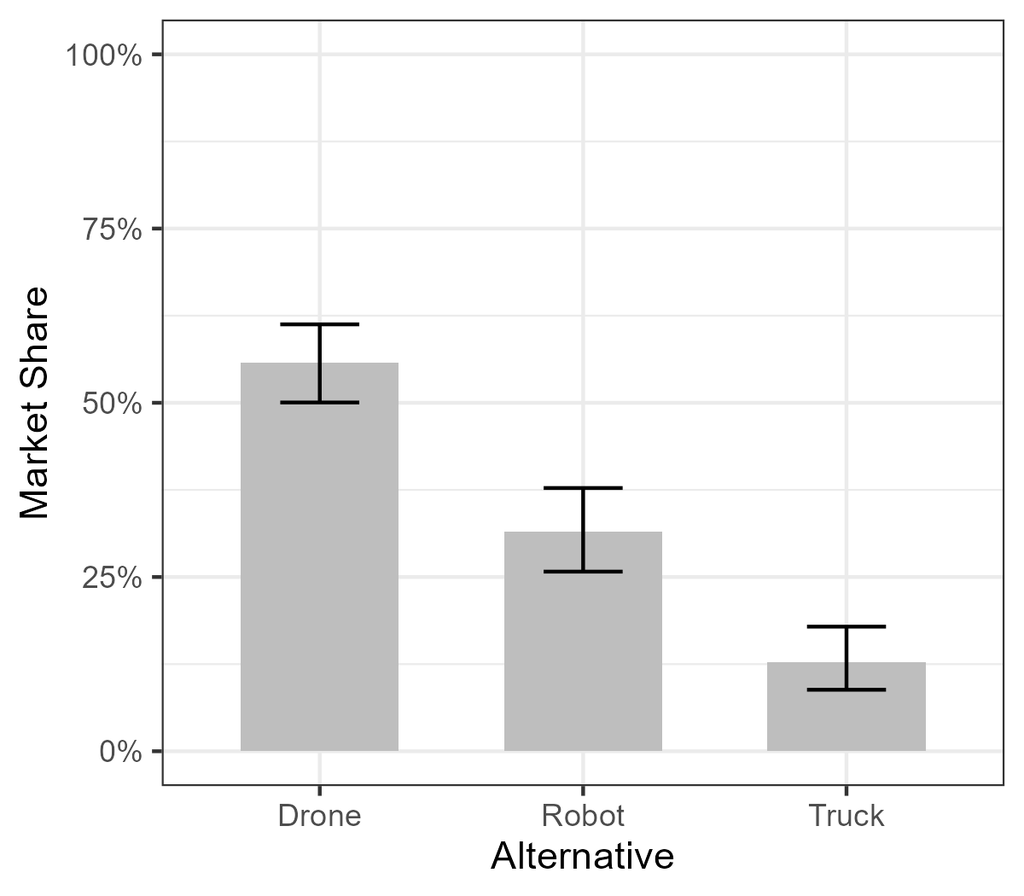

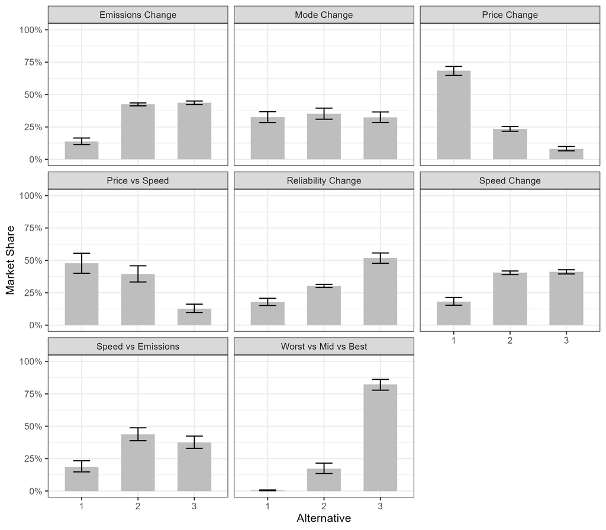

**Key Insights from Market Simulations**

- **Price is the strongest driver of market share.** Reducing price leads to the largest increases in predicted adoption, making it the most influential attribute in shaping consumer preference.
- **Reliability is the most impactful non-price attribute.** Moving from low to high reliability produces a substantial jump in market share, indicating that consumers heavily value trustworthy and consistent delivery performance.
- **Speed improvements matter, but only up to a point.** Reducing delivery time from 24 hours to 1 hour significantly boosts preference, but the additional improvement from 1 hour to 0.5 hours provides only a small incremental gain.
- **Emissions reductions are valued, but less than reliability or price.** Lowering emissions increases share meaningfully, though the effect is weaker compared to high reliability or lower price.
- **Changing delivery mode alone (Drone, Robot, Truck) does not materially shift consumer preference.** When all other attributes are held constant, consumers show similar market shares across modes, suggesting that **performance attributes drive choice more than delivery method**.
- **Overall market adoption is maximized by combinations of:**
  - Lower price
  - Higher reliability
  - Faster delivery (major improvements only)
  - Lower emissions

These findings highlight that **improving reliability and optimizing price strategy** offer the greatest opportunities to increase consumer demand, with speed and emissions offering secondary advantages.

## Sensitivity Analysis

### Tornado Plot – Sensitivity to Other Attributes

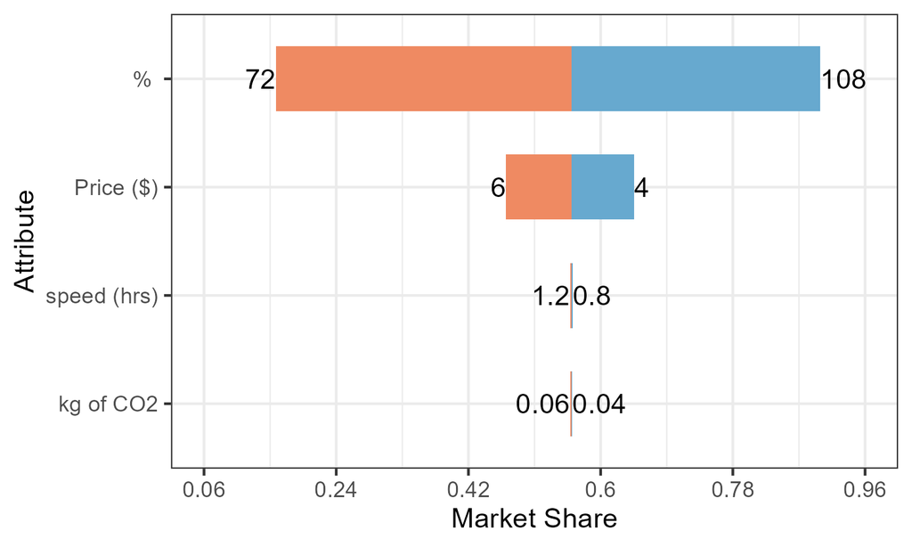

- The tornado plot summarizes how the drone’s market share responds to **±20% changes** in each attribute relative to the baseline (price = $5, speed = 1 hr, emissions = 0.05 kg CO₂, reliability = 90%).
- **Reliability** is by far the most influential non-price attribute:
  - Increasing reliability from 90% to **108%** (a stylized “very high reliability” case) increases predicted share from about **0.56 to 0.90**.
  - Decreasing reliability to **72%** collapses share to roughly **0.16**.
  - This very wide bar dominates the tornado chart, indicating that reliability is the **primary design lever** beyond price.
- **Price** has the next-largest impact:
  - Lowering price by 20% (to **$4**) raises share to about **0.64**, while increasing price by 20% (to **$6**) reduces share to about **0.47**.
  - This confirms the strong price sensitivity already visible in the price–share plot.
- **Speed** (1 hr → 0.8 hr or 1.2 hr) and **emissions** (0.05 → 0.04 or 0.06 kg CO₂) have **very small effects** on market share in comparison:
  - Predicted shares remain clustered around the baseline (≈ 0.56), with only minor deviations, indicating that small ±20% changes in these attributes do not dramatically shift demand in this configuration.

### Design & Pricing Recommendations (with Uncertainty)

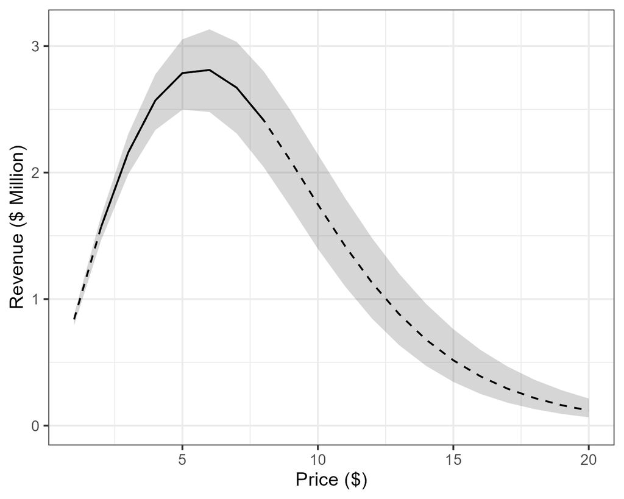

- **Best price point (revenue-maximizing):**
  - The revenue curve peaks around **$5–$6**, with overlapping 95% CIs, so this range should be treated as the **optimal pricing band** rather than a single exact value.
  - Pricing significantly below $5 sacrifices revenue (too much margin lost), while pricing above $6 rapidly erodes both share and revenue.
- **Key design decisions to maximize demand:**
  - **Prioritize reliability**: moving toward very high reliability levels produces the largest gains in market share and should be a central engineering and operations target.
  - **Use price strategically**: modest under-pricing (e.g., closer to $5 than $6) can secure higher share without sacrificing too much revenue.
  - **Maintain reasonable speed and low emissions**, but recognize that, within the tested ranges, incremental improvements in these attributes are **less impactful** than reliability and price.
- Overall, the sensitivity analysis indicates that **reliability and price are the dominant drivers of market demand**, while speed and emissions play supporting roles. The uncertainty bands around all plots remind us that these estimates are not exact; instead, they define **plausible ranges** within which the true optimal price and attribute levels likely lie.

# Final Recommendations and Conclusions

## Recommended Price Range and Revenue Implications

Sensitivity analysis of price demonstrated that market share declines smoothly as price increases, with revenue peaking at approximately **$5–6**, where both adoption and total revenue are maximized. At prices below $4, revenue falls due to margin constraints, while prices above $7 lead to steep declines in market share. Based on the revenue curve and its associated confidence intervals, the optimal price point is **$5**, with reasonable robustness across the confidence band. Estimates remain consistent across simulations, giving moderate confidence in the recommendation, though real-world factors such as retailer partnerships, promotional pricing, or operational costs could shift the optimal point slightly.